# AIML Module Project - Computer Vision - Part A - Aaditya Kumar Ravi

#### Part A - 20 Marks

**• DOMAIN:** Entertainment

**• DATA DESCRIPTION:** The dataset comprises of images and its mask for corresponding human face.

**• PROJECT OBJECTIVE:** To build a face detection system.

**Steps and tasks: [ Total Score: 20 Marks]**

## 1. Import and Understand the data [7 Marks]

```python
#Let us mount the google drive first
from google.colab import drive
drive.mount('/content/drive')
```

```python
# Importing some of the libraries to be used
import numpy as np
import pandas as pd
import matplotlib.pyplot as plt
import cv2
import os
import random

from sklearn.model_selection import train_test_split

import tensorflow as tf
from tensorflow import keras
from keras.applications import MobileNetV2
from keras.layers import Input, Conv2D, UpSampling2D, Concatenate, BatchNormalization, Activation
from keras.models import Model, load_model
from keras.optimizers import Adam
from keras.callbacks import EarlyStopping, ModelCheckpoint, ReduceLROnPlateau
from keras.metrics import Recall, Precision
from keras.losses import binary_crossentropy
import matplotlib.ticker as ticker
```

### A. Import and read ‘images.npy’. [1 Marks]

```python
images = np.load('/content/drive/MyDrive/Colab Notebooks/Images.npy', allow_pickle=True)
```

```python
# Printing image array at first position
print(images[0])
```

```
[array([[[42, 37, 34],
         [56, 51, 48],
         [71, 66, 63],
         ...,
         [23, 33, 34],
         [26, 36, 37],
         [28, 38, 39]],

        [[40, 35, 32],
         [51, 46, 43],
         [64, 59, 56],
         ...,
         [27, 36, 35],
         [24, 33, 32],
         [26, 35, 34]],

        [[43, 38, 35],
         [51, 46, 43],
         [61, 56, 53],
         ...,
         [28, 30, 27],
         [33, 35, 32],
         [35, 37, 34]],

        ...,

        [[56, 47, 40],
         [57, 48, 41],
         [61, 52, 45],
         ...,
         [67, 48, 42],
         [55, 35, 28],
         [60, 40, 33]],

        [[53, 44, 37],
         [54, 45, 38],
         [57, 48, 41],
         ...,
         [59, 40, 34],
         [60, 40, 33],
         [54, 34, 27]],

        [[53, 44, 37],
         [54, 45, 38],
         [57, 48, 41],
         ...,
         [59, 40, 34],
         [70, 50, 43],
         [64, 44, 37]]], dtype=uint8)
 list([{'label': ['Face'], 'notes': '', 'points': [{'x': 0.08615384615384615, 'y': 0.3063063063063063}, {'x': 0.1723076923076923, 'y': 0.45345345345345345}], 'imageWidth': 650, 'imageHeight': 333}, {'label': ['Face'], 'notes': '', 'points': [{'x': 0.583076923076923, 'y': 0.2912912912912913}, {'x': 0…
```

- The dataset contains images and its mask for corresponding human face.

```python
images.shape
```

```
(393, 2)
```

- It has 393 rows and 2 columns.

```
ndarray (333, 650, 3)
```

[figure not shown]

```
array([[[42, 37, 34],
        [56, 51, 48],
        [71, 66, 63],
        ...,
        [23, 33, 34],
        [26, 36, 37],
        [28, 38, 39]],

       [[40, 35, 32],
        [51, 46, 43],
        [64, 59, 56],
        ...,
        [27, 36, 35],
        [24, 33, 32],
        [26, 35, 34]],

       [[43, 38, 35],
        [51, 46, 43],
        [61, 56, 53],
        ...,
        [28, 30, 27],
        [33, 35, 32],
        [35, 37, 34]],

       ...,

       [[56, 47, 40],
        [57, 48, 41],
        [61, 52, 45],
        ...,
        [67, 48, 42],
        [55, 35, 28],
        [60, 40, 33]],

       [[53, 44, 37],
        [54, 45, 38],
        [57, 48, 41],
        ...,
        [59, 40, 34],
        [60, 40, 33],
        [54, 34, 27]],

       [[53, 44, 37],
        [54, 45, 38],
        [57, 48, 41],
        ...,
        [59, 40, 34],
        [70, 50, 43],
        [64, 44, 37]]], dtype=uint8)
```

```python
# Image array for record at 0th index
images[0][0]
```

```python
# Mask for image at 0th index
images[0][1]
```

```
[{'label': ['Face'],
  'notes': '',
  'points': [{'x': 0.08615384615384615, 'y': 0.3063063063063063},
   {'x': 0.1723076923076923, 'y': 0.45345345345345345}],
  'imageWidth': 650,
  'imageHeight': 333},
 {'label': ['Face'],
  'notes': '',
  'points': [{'x': 0.583076923076923, 'y': 0.2912912912912913},
   {'x': 0.6584615384615384, 'y': 0.46846846846846846}],
  'imageWidth': 650,
  'imageHeight': 333}]
```

- Mask for the image contains 5 properties: Label, notes, points coordinates, imageWidth and imageHeight.
- For this image, It is twice it means its label indicate, this image has 2 faces.

```
Size of image at index 0 : (333, 650, 3)
```

[figure not shown]

```
Size of image at index 1 : (697, 1280, 4)
```

[figure not shown]

```
Size of image at index 2 : (291, 600, 4)
```

[figure not shown]

```
Size of image at index 3 : (326, 580, 3)
```

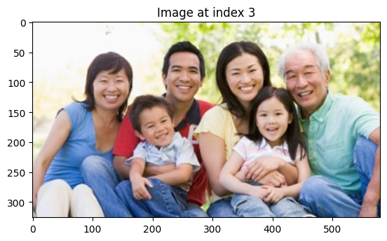

```
Size of image at index 4 : (500, 500, 3)
```

[figure not shown]

```python
# Let us view a few images in this dataset.
for i in range(5):
    print("Size of image at index",i,":",images[i][0].shape)
    plt.imshow(images[i][0], cmap="gray")
    plt.title("Image at index {}".format(i))
    plt.show()
```

- We observe that all the images are of different sizes.
- Image at index 0,3,4 follows RGB color format, whereas looks like image at index 1,2 follows RGBA(Red, Green, Blue and Alpha i.e Transparancy) color format. We have some images GrayScale as well.

### B. Split the data into Features(X) & labels(Y). Unify shape of all the images. [3 Marks]

- Imp Note: Replace all the pixels within masked area with 1.
- Hint: X will comprise of array of image whereas Y will comprise of coordinates of the mask(human face). Observe: data[0], data[0][0], data[0][1]
- We will be unifying shape of each image to make it 224 * 224 * 3

```python
# Declaring image size and channel as constants
WIDTH = 224
HEIGHT = 224
CHANNEL = 3 # Assuming 3 channels only RGB in order to unify shape, ignoring 4th color Alpha(transparency) for some of the images

num_records = images.shape[0]

# Create array with zeros assigned initially, we will use this variable to store resized image and its mask information
image = np.zeros((int(num_records), HEIGHT, WIDTH, CHANNEL), dtype=np.float32)
mask = np.zeros((int(num_records), HEIGHT, WIDTH), dtype=np.float32)

for i in range(num_records):
  resized_image = cv2.resize(images[i][0], (WIDTH, HEIGHT), interpolation=cv2.INTER_CUBIC) # Assigned resized images in image variable

  if resized_image.ndim == 2:  # Grayscale image (shape: (HEIGHT, WIDTH))
    resized_image = cv2.cvtColor(resized_image, cv2.COLOR_GRAY2RGB)
  elif resized_image.shape[2] == 4:  # RGBA image (shape: (HEIGHT, WIDTH, 4))
    resized_image = cv2.cvtColor(resized_image, cv2.COLOR_RGBA2RGB)
  # RGB image (shape: (HEIGHT, WIDTH, 3)) does not need conversion as we have defined image to accept RGB format.

  image[i] = keras.applications.mobilenet_v2.preprocess_input(np.array(resized_image, dtype=np.float32))

  # Procesing each mask
  for m in images[i][1]: # Loop through its mask(label)
    x1 = int(m['points'][0]['x']*WIDTH)
    y1 = int(m['points'][0]['y']*HEIGHT)
    x2 = int(m['points'][1]['x']*WIDTH)
    y2 = int(m['points'][1]['y']*HEIGHT)
    #label = m['label']
    #if label == 'face':
    mask[i][y1:y2, x1:x2] = 1

print("Image Detail Shape:", image.shape)
print("Mask Detail Shape:", mask.shape)

# Assigning it to asked variable
X = image #Feature
Y = mask  #Label
```

```
Image Detail Shape: (393, 224, 224, 3)
Mask Detail Shape: (393, 224, 224)
```

**Let us show 10 resized images in 2 lines to verify if images are looking properly.**

[output not shown]

[figure not shown]

[output not shown]

[figure not shown]

```python
for i in range(2): # Represents line
    plt.figure(figsize=(15, 10))
    for j in range(5): # Represents image per line
        plt.subplot(2, 5, j + 1) # Setup 2*5 grid for subplots
        plt.imshow(X[i * 5 + j]) # Index calculation for each line
        plt.title("Image at index {}".format(i * 5 + j))
        plt.axis("off")
    plt.show()
```

- Yes the images are looking unified, resized and good.

### C. Split the data into train and test[400:9]. [1 Marks]

```python
# Since only 393 records are present in images npy instead of 409, we are spliting train and test data in 90:10% ratio
train_X, test_X, train_Y, test_Y = train_test_split(X, Y, test_size=0.1, random_state=42)

print('\nTraining data : ', train_X.shape, train_Y.shape)
print('\nTesting data : ', test_X.shape, test_Y.shape)
print('\nTraining data =',round(train_X.shape[0]*100/(train_X.shape[0]+test_X.shape[0]),2),"% of total data")
print('\nTesting data =',round(test_X.shape[0]*100/(train_X.shape[0]+test_X.shape[0]),2),"% of total data")
```

```
Training data :  (353, 224, 224, 3) (353, 224, 224)

Testing data :  (40, 224, 224, 3) (40, 224, 224)

Training data = 89.82 % of total data

Testing data = 10.18 % of total data
```

### D. Select random image from the train data and display original image and masked image. [2 Marks]

```
WARNING:matplotlib.image:Clipping input data to the valid range for imshow with RGB data ([0..1] for floats or [0..255] for integers).
```

```
Displaying image at index: 178
```

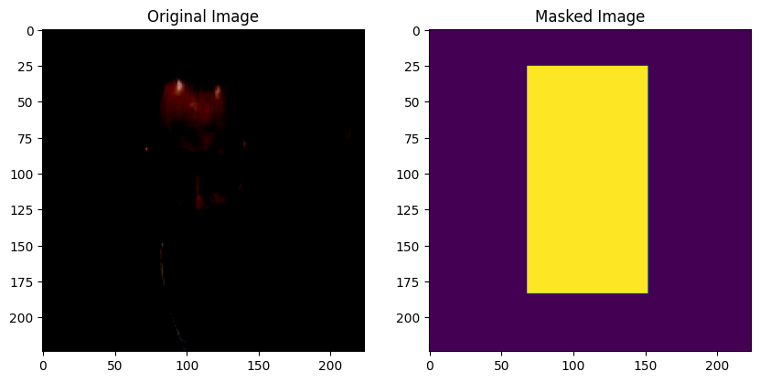

```python
import random

random_index = random.randint(0, len(train_X) - 1)
print("Displaying image at index:", random_index)

# Get the original and masked images
original_image = train_X[random_index]
masked_image = train_Y[random_index]

# Display the original image and masked image side by side
fig, axs = plt.subplots(1, 2, figsize=(10, 5))
axs[0].imshow(original_image)
axs[0].set_title('Original Image')

axs[1].imshow(masked_image)
axs[1].set_title('Masked Image')
plt.show()
```

[output not shown]

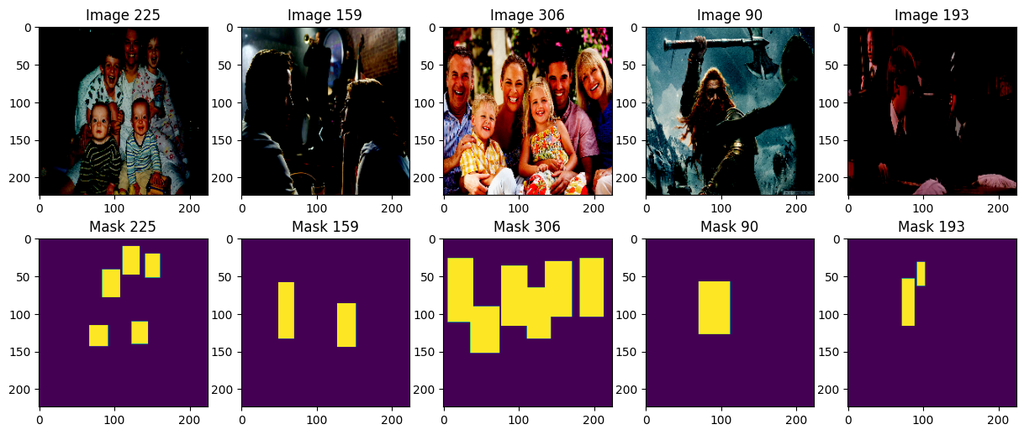

```python
# Show random 5 original images in one line and its corresponding masked image in 2nd line
plt.figure(figsize=(15, 6))
for i in range(5):
    random_index = random.randint(0, len(train_X) - 1)

    original_image = train_X[random_index]
    masked_image = train_Y[random_index]

    plt.subplot(2, 5, i + 1)
    plt.imshow(original_image)
    plt.title("Image {}".format(random_index))

    plt.subplot(2, 5, i + 6)
    plt.imshow(masked_image)
    plt.title("Mask {}".format(random_index))
```

## 2. Model building [11 Marks]

### A. Design a face mask detection model. [4 Marks]

- Hint: 1. Use MobileNet architecture for initial pre-trained non-trainable layers.
- Hint: 2. Add appropriate Upsampling layers to imitate U-net architecture.

MobileNetV2 is the newer version of MobileNet(MobileNetV1), we will use this as MobileNetV2 has drastically lower parameter count than the MobileNetV1.

We will follow below steps for this face mask detection model:

1. Load and freeze the MobileNetV2 base model
2. Add U-net like upsampling layers
3. Compile and train the model

```python
# Designing a face mask detection model
def face_mask_detection_model():
  inputs = Input(shape=(HEIGHT, WIDTH, 3),name="input")

  # Load the base model
  base_model = MobileNetV2(
      input_tensor=inputs,
      include_top=False,
      weights="imagenet",
      alpha=0.35,
  )

  # Freeze the MobileNet layers
  for layer in base_model.layers:
      layer.trainable = False

  skip_connection_names = [
      "input",
      "block_1_expand_relu",
      "block_3_expand_relu",
      "block_6_expand_relu"
  ]

  outputs = base_model.get_layer("block_13_expand_relu").output

  filters = [16, 32, 48, 64]

  x = outputs
  for i in range(len(skip_connection_names)-1,-1, -1):
      print(i, filters[i])
      x_skip = base_model.get_layer(skip_connection_names[i]).output
      x = UpSampling2D([2,2])(x)
      x = Concatenate()([x, x_skip])

      x = Conv2D(filters[i], (3, 3), padding="same")(x)
      x = BatchNormalization()(x)
      x = Activation("relu")(x)

      x = Conv2D(filters[i], (3, 3), padding="same")(x)
      x = BatchNormalization()(x)
      x = Activation("relu")(x)

  x = Conv2D(1, (1, 1), padding="same")(x)
  x = Activation("sigmoid")(x)

  model = Model(inputs, x)
  return model

# Call the designed model function
model = face_mask_detection_model()
model.summary()
```

```
WARNING:tensorflow:`input_shape` is undefined or non-square, or `rows` is not in [96, 128, 160, 192, 224]. Weights for input shape (224, 224) will be loaded as the default.
```

```
Downloading data from https://storage.googleapis.com/tensorflow/keras-applications/mobilenet_v2/mobilenet_v2_weights_tf_dim_ordering_tf_kernels_0.35_224_no_top.h5
3 64
2 48
1 32
0 16
Model: "model"
__________________________________________________________________________________________________
 Layer (type)                Output Shape                 Param #   Connected to
==================================================================================================
 input (InputLayer)          [(None, 224, 224, 3)]        0         []

 Conv1 (Conv2D)              (None, 112, 112, 16)         432       ['input[0][0]']

 bn_Conv1 (BatchNormalizati  (None, 112, 112, 16)         64        ['Conv1[0][0]']
 on)

 Conv1_relu (ReLU)           (None, 112, 112, 16)         0         ['bn_Conv1[0][0]']

 expanded_conv_depthwise (D  (None, 112, 112, 16)         144       ['Conv1_relu[0][0]']
 epthwiseConv2D)

 expanded_conv_depthwise_BN  (None, 112, 112, 16)         64        ['expanded_conv_depthwise[0][0
  (BatchNormalization)                                              ]']

 expanded_conv_depthwise_re  (None, 112, 112, 16)         0         ['expanded_conv_depthwise_BN[0
 lu (ReLU)                                                          ][0]']

 expanded_conv_project (Con  (None, 112, 112, 8)          128       ['expanded_conv_depthwise_relu
 v2D)                                                               [0][0]']

 expanded_conv_project_BN (  (None, 112, 112, 8)          32        ['expanded_conv_project[0][0]'
 BatchNormalization)                                                ]

 block_1_expand (Conv2D)     (None, 112, 112, 48)         384       ['expanded_conv_project_BN[0][
                                                                    0]']

 block_1_expand_BN (BatchNo  (None, 112, 112, 48)         192       ['block_1_expand[0][0]']
 rmalization)

 block_1_expand_relu (ReLU)  (None, 112, 112, 48)         0         ['block_1_expand_BN[0][0]']
```

[output cut: 383 more lines]

```
 batch_normalization_7 (Bat  (None, 224, 224, 16)         64        ['conv2d_7[0][0]']
 chNormalization)

 activation_7 (Activation)   (None, 224, 224, 16)         0         ['batch_normalization_7[0][0]'
                                                                    ]

 conv2d_8 (Conv2D)           (None, 224, 224, 1)          17        ['activation_7[0][0]']

 activation_8 (Activation)   (None, 224, 224, 1)          0         ['conv2d_8[0][0]']

==================================================================================================
Total params: 416209 (1.59 MB)
Trainable params: 317057 (1.21 MB)
Non-trainable params: 99152 (387.31 KB)
__________________________________________________________________________________________________
```

### B. Design your own Dice Coefficient and Loss function. [2 Marks]

- The Dice coefficient, also known as the Dice similarity index or F1 score, is a statistical measure used to measure the similarity between two sets.
- Dice coefficient ranges from 0 to 1, where 0 indicates no overlap and 1 signifies perfect overlap between the predicted and ground truth masks.
- We will add epsilon(a small value) to both numerator and denominator in the formula of dice coefficient which ensures that it would not be in divide by zero condition or Dice Coefficient does not drop to zero too harshly in case of no overlap between ground truth and predicted mask and maintains a more gradual and stable learning curve.

```python
# Dice Coefficient
def dice_coefficient(y_true, y_pred):
  '''
  y_true: Ground truth mask
  y_pred: Predicted mask
  '''
  smooth = keras.backend.epsilon()
  intersection = tf.reduce_sum(y_true * y_pred)
  summation = tf.reduce_sum(y_true) + tf.reduce_sum(y_pred)
  dc = (2 * intersection + smooth ) / (summation + smooth)
  return dc

def dice_loss(y_true, y_pred):
  '''
  y_true: Ground truth mask
  y_pred: Predicted mask
  '''
  return 1 - dice_coefficient(y_true, y_pred)

# Combined Binary Cross Entropy and Dice Loss function
def combined_bce_dice_loss(y_true, y_pred):
    '''
    y_true: Ground truth mask
    y_pred: Predicted mask
    '''
    bce = binary_crossentropy(y_true, y_pred)
    dice = dice_coefficient(y_true, y_pred)
    log_dice = keras.backend.log(dice + tf.keras.backend.epsilon())
    return bce - log_dice
```

### C. Train and tune the model as required. [3 Marks]

```python
model.compile(optimizer='adam', loss=combined_bce_dice_loss, metrics=[dice_coefficient, Recall(), Precision()])

callbacks = [
    EarlyStopping(monitor='val_loss',patience=10, restore_best_weights=False, verbose=1),
    ReduceLROnPlateau(monitor='val_loss', factor=0.1, patience=5, min_lr=0.00001, verbose=1),
    ModelCheckpoint('model-face-mask-detect.h5', verbose=1, save_best_only=True, save_weights_only=True)
]

history = model.fit(train_X, train_Y, epochs=32, callbacks=callbacks, batch_size=10, validation_split=0.1, verbose=1)
```

```
Epoch 1: val_loss improved from inf to 10.59650, saving model to model-face-mask-detect.h5
Epoch 2: val_loss improved from 10.59650 to 7.41154, saving model to model-face-mask-detect.h5
Epoch 3: val_loss improved from 7.41154 to 3.29631, saving model to model-face-mask-detect.h5
Epoch 4: val_loss improved from 3.29631 to 1.69924, saving model to model-face-mask-detect.h5
Epoch 5: val_loss improved from 1.69924 to 1.08364, saving model to model-face-mask-detect.h5
Epoch 6: val_loss did not improve from 1.08364
Epoch 7: val_loss improved from 1.08364 to 0.90526, saving model to model-face-mask-detect.h5
Epoch 8: val_loss improved from 0.90526 to 0.77296, saving model to model-face-mask-detect.h5
Epoch 9: val_loss did not improve from 0.77296
Epoch 10: val_loss improved from 0.77296 to 0.74085, saving model to model-face-mask-detect.h5
Epoch 11: val_loss did not improve from 0.74085
Epoch 12: val_loss did not improve from 0.74085
Epoch 13: val_loss did not improve from 0.74085
Epoch 14: val_loss did not improve from 0.74085
Epoch 15: ReduceLROnPlateau reducing learning rate to 0.00010000000474974513.

Epoch 15: val_loss did not improve from 0.74085
Epoch 16: val_loss did not improve from 0.74085
Epoch 17: val_loss did not improve from 0.74085
Epoch 18: val_loss did not improve from 0.74085
Epoch 19: val_loss did not improve from 0.74085
Epoch 20: ReduceLROnPlateau reducing learning rate to 1.0000000474974514e-05.

Epoch 20: val_loss did not improve from 0.74085
Epoch 20: early stopping
```

- Dice coefficient 0.83, recall and precision on training data is 0.87 which is good.
- Loss on final epoch training data is 0.27 which is also good.
- It is just that on the validation data dice coefficient is 0.55, recall is 0.46 and precision is 0.77 which is low compared to the results we got on training data.
- Model has scope of improvement, we can make our model more complex to get better performance but it will take more compute time.

### D. Evaluate and share insights on performance of the model. [2 Marks]

```python
Y_pred = model.predict(test_X)
results = model.evaluate(test_X, test_Y)
```

[output not shown]

- We are getting loss of 0.80, dice coefficient of 0.61, recall of 0.51 and precision of 0.80.
- There is scope of improvement on the model, it is going towards little bit overfitting where we have very good score on training data but lacking behind on validation and test data.
- Loss has also increased in testing stage. In training loss was 0.27 and in testing stage loss is 0.8 which is not good.

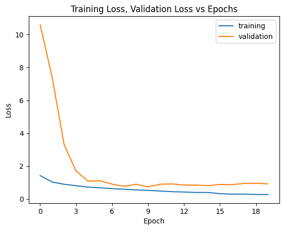

```python
h = pd.DataFrame(history.history)
h['epoch'] = history.epoch
plt.xlabel('Epoch')
plt.ylabel('Loss')
plt.title("Training Loss, Validation Loss vs Epochs")
plt.plot(h['loss'])
plt.plot(h['val_loss'])
plt.legend(("training" , "validation") , loc=0);
plt.gca().xaxis.set_major_locator(ticker.MaxNLocator(integer=True))
```

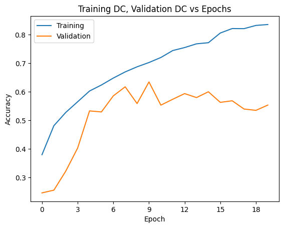

```python
plt.title("Training DC, Validation DC vs Epochs")
plt.plot(h['dice_coefficient'])
plt.plot(h['val_dice_coefficient'])
plt.xlabel('Epoch')
plt.ylabel('Accuracy')
plt.legend(("Training" , "Validation") , loc=0);
plt.gca().xaxis.set_major_locator(ticker.MaxNLocator(integer=True))
```

- Training Dice coefficient is improving as epoch is increasing but validation dice coefficient started decreasing after 9 epochs and even between 9 to 18 epochs it did not improve much.

```python
# Let us save this model so that we can load this and use it without need to retraining
model.save('/content/drive/MyDrive/Colab Notebooks/model-face-mask-detect.keras')
```

```python
# Verify if model saved
os.path.exists('/content/drive/MyDrive/Colab Notebooks/model-face-mask-detect.keras')
```

```
True
```

```python
# Load the model for further use
loaded_model = load_model('/content/drive/MyDrive/Colab Notebooks/model-face-mask-detect.keras', custom_objects={
    'dice_coefficient': dice_coefficient,
    'combined_bce_dice_loss': combined_bce_dice_loss
})
```

### 3. Test the model predictions on the test image: ‘image with index 3 in the test data’ and visualise the predicted masks on the faces in the image. [2 Marks]

```python
# Predict the mask for image at index 3
pred_3 = model.predict(np.expand_dims(np.array(test_X[3]),axis=0))
```

```
WARNING:matplotlib.image:Clipping input data to the valid range for imshow with RGB data ([0..1] for floats or [0..255] for integers).
```

[figure not shown]

```python
image_3 = test_X[3]
predicted_3 = pred_3[0]

# Display the original image and masked image side by side
fig, axs = plt.subplots(1, 2, figsize=(10, 5))
axs[0].imshow(image_3)
axs[0].set_title('Image with index 3')

axs[1].imshow(predicted_3)
axs[1].set_title('Predicted Mask at index 3')

plt.show()
```

We can see our model has accurately predicted 5 face masks for the image at index 3.

**Note: Remaining answers of part B and C are in another file.**